# **Assignment 9**

- Use the data set “/Data/GradSchool_Admissions.csv”
- You will explore and model the predictors of graduate school admission
  - the “admit” column is coded as 1=success and 0=failure (that’s binary, so model appropriately)
  - the other columns are the GRE score, the GPA, and the rank of the undergraduate institution, where I is “top-tier.”
- Document your data explorations, figures, and conclusions in a reproducible R-markdown report
- That means I want to see, in your html report, your process of model evaluation and selection. Here’s an [example](https://gzahn.github.io/data-course/Repository/Assignments/Assignment_9/example.html)
- Upload your **self-contained** R project, including knitted HTML report, to GitHub in *your* Assignment_9 directory

##Alright, let’s get started.

```r
##Any variables I'm using.
#gradad - gradschool admissions csvs
#modgrad - the model for the gradschool acceptance.
#modsmol - the second model for this, smaller

#libraries loading
library(tidyverse)
```

```r
library(ggplot2)
library(modelr)
library(dplyr)
library(hexbin)

#Loading in the data.
gradad <- read.csv("../../Data/GradSchool_Admissions.csv")

#Taking a looksie
glimpse(gradad)
```

```
## Rows: 400
## Columns: 4
## $ admit <int> 0, 1, 1, 1, 0, 1, 1, 0, 1, 0, 0, 0, 1, 0, 1, 0, 0, 0, 0, 1, 0, 1…
## $ gre   <int> 380, 660, 800, 640, 520, 760, 560, 400, 540, 700, 800, 440, 760,…
## $ gpa   <dbl> 3.61, 3.67, 4.00, 3.19, 2.93, 3.00, 2.98, 3.08, 3.39, 3.92, 4.00…
## $ rank  <int> 3, 3, 1, 4, 4, 2, 1, 2, 3, 2, 4, 1, 1, 2, 1, 3, 4, 3, 2, 1, 3, 2…
```

```r
str(gradad)
```

```
## 'data.frame':    400 obs. of  4 variables:
##  $ admit: int  0 1 1 1 0 1 1 0 1 0 ...
##  $ gre  : int  380 660 800 640 520 760 560 400 540 700 ...
##  $ gpa  : num  3.61 3.67 4 3.19 2.93 3 2.98 3.08 3.39 3.92 ...
##  $ rank : int  3 3 1 4 4 2 1 2 3 2 ...
```

First we need to clean the data set.

```r
#Changing rank to a factor instead of whatever it is now.
gradad$rank <- as.factor(gradad$rank)
#colSums(is.na(gradad))
```

Epic, very cool. Now let’s go ahead and mess around with the data.

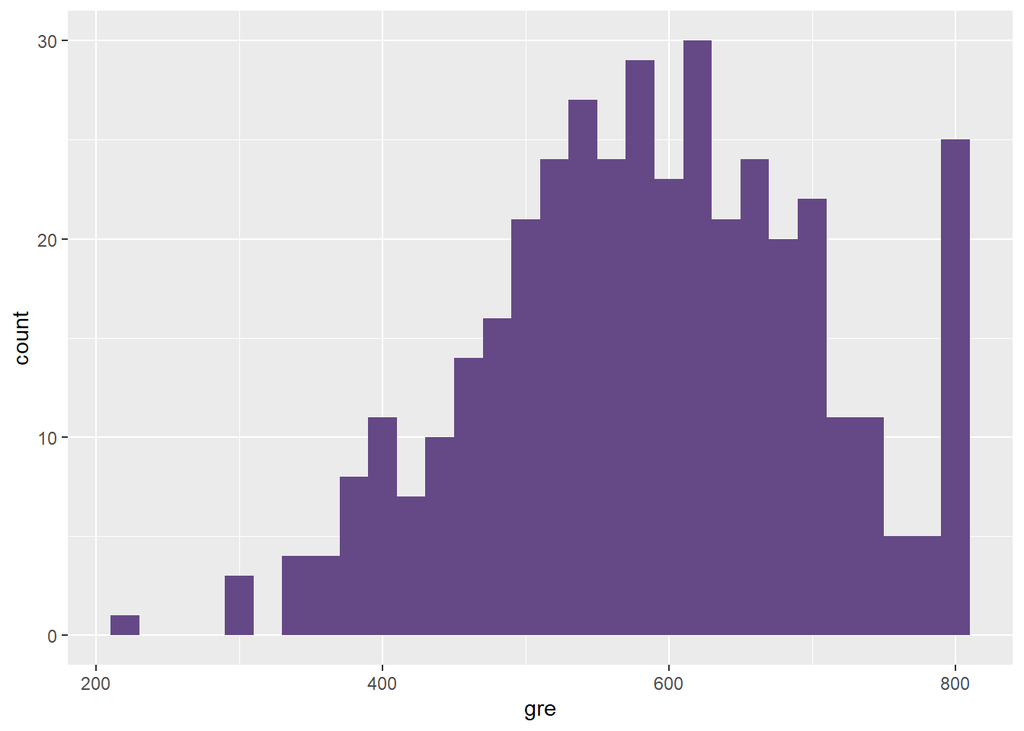

```r
#Going off vibes man.
#Let's mess with gre
ggplot(gradad, aes(x = gre)) + geom_histogram(bins = 30, fill = "#654986")
```

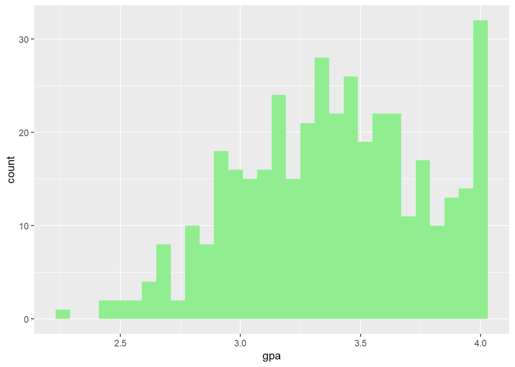

```r
#Gonna be real. No idea what a gre score is, so no idea how to interprit this. I may be stupid.

#Now let's mess with gpa
ggplot(gradad, aes(x = gpa)) + geom_histogram(bins = 30, fill = "lightgreen")
```

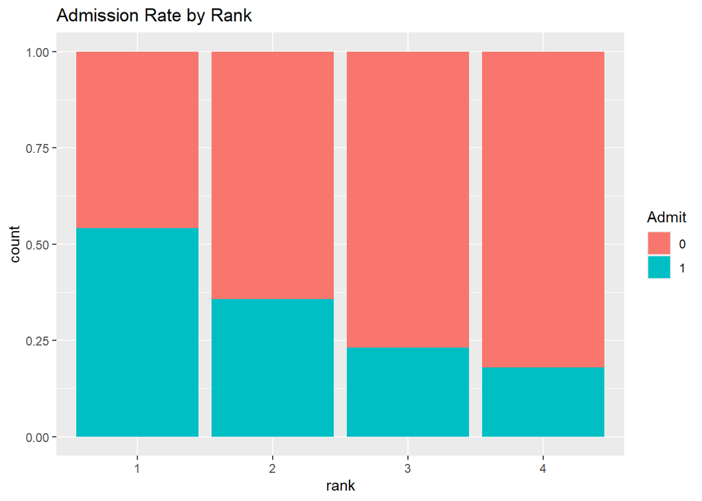

```r
#Am I dumb, or is that the exact same shape and distribution?

#I guess it is almost. Well, that was just sort of exploring what the data looked like. Now let's mess with other stuff.

#looking by rank at admission.
ggplot(gradad, aes(x = rank, fill = as.factor(admit))) + geom_bar(position = "fill") + labs(title = "Admission Rate by Rank", fill = "Admit")
```

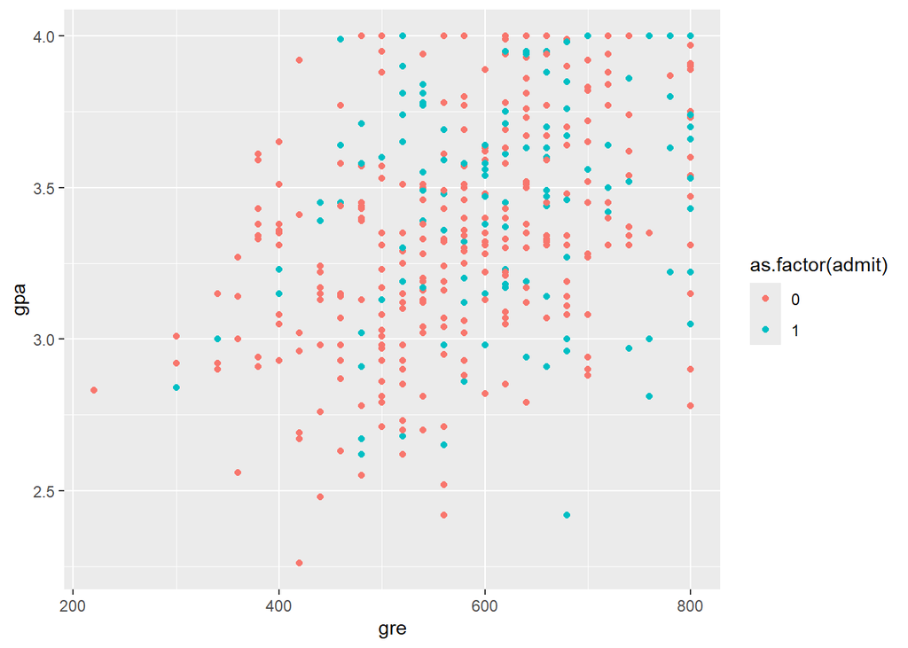

```r
#I again, don't really know what's going on with this graph. Looks neat.

#Now let's compare two variables rather than just looking at one at a time.
#Or, I guess we did that with the last one. But I didn't fully know what that meant.
ggplot(gradad, aes(x = gre, y = gpa, color = as.factor(admit))) + geom_point()
```

```r
#This one to me indicates that higher gpa and higher gre makes it more likely to be admitted. It seems to me though that the gre matters more than the gpa, as I see more 1 dots clustered around the right side of the x axis.
```

Alright, let’s make the model itself now.

```r
#With the help of ChatGPT, shoutout.
modgrad <- glm(admit ~ gre + gpa + rank, data = gradad, family = binomial)
summary(modgrad)
```

```
##
## Call:
## glm(formula = admit ~ gre + gpa + rank, family = binomial, data = gradad)
##
## Coefficients:
##              Estimate Std. Error z value Pr(>|z|)
## (Intercept) -3.989979   1.139951  -3.500 0.000465 ***
## gre          0.002264   0.001094   2.070 0.038465 *
## gpa          0.804038   0.331819   2.423 0.015388 *
## rank2       -0.675443   0.316490  -2.134 0.032829 *
## rank3       -1.340204   0.345306  -3.881 0.000104 ***
## rank4       -1.551464   0.417832  -3.713 0.000205 ***
## ---
## Signif. codes:  0 '***' 0.001 '**' 0.01 '*' 0.05 '.' 0.1 ' ' 1
##
## (Dispersion parameter for binomial family taken to be 1)
##
##     Null deviance: 499.98  on 399  degrees of freedom
## Residual deviance: 458.52  on 394  degrees of freedom
## AIC: 470.52
##
## Number of Fisher Scoring iterations: 4
```

```r
#Gonna be so real right now, the way this is is meaningless to me. I don't understand it.
#ChatGPT said this was the interpritation: GRE: Positive coefficient suggests higher GRE increases admission probability.
#GPA: Typically strong positive predictor.
#Rank: Lower-tier schools (higher rank number) usually reduce admission odds.
#Maybe it is, I have no idea. I liked the graph better. And I think I got the idea from the graph

#Let's make another model now to compare.
modsmol <- glm(admit ~ gpa + rank,
                     data = gradad,
                     family = binomial)
summary(modsmol)
```

```
##
## Call:
## glm(formula = admit ~ gpa + rank, family = binomial, data = gradad)
##
## Coefficients:
##             Estimate Std. Error z value Pr(>|z|)
## (Intercept)  -3.4636     1.1003  -3.148 0.001645 **
## gpa           1.0521     0.3102   3.392 0.000694 ***
## rank2        -0.6810     0.3141  -2.168 0.030181 *
## rank3        -1.3919     0.3419  -4.071 4.68e-05 ***
## rank4        -1.5943     0.4152  -3.840 0.000123 ***
## ---
## Signif. codes:  0 '***' 0.001 '**' 0.01 '*' 0.05 '.' 0.1 ' ' 1
##
## (Dispersion parameter for binomial family taken to be 1)
##
##     Null deviance: 499.98  on 399  degrees of freedom
## Residual deviance: 462.88  on 395  degrees of freedom
## AIC: 472.88
##
## Number of Fisher Scoring iterations: 4
```

```r
#Again, no idea what this means.
#But let's compare them anyway.
anova(modsmol, modgrad, test = "Chisq")
```

```
## Analysis of Deviance Table
##
## Model 1: admit ~ gpa + rank
## Model 2: admit ~ gre + gpa + rank
##   Resid. Df Resid. Dev Df Deviance Pr(>Chi)
## 1       395     462.88
## 2       394     458.52  1   4.3578  0.03684 *
## ---
## Signif. codes:  0 '***' 0.001 '**' 0.01 '*' 0.05 '.' 0.1 ' ' 1
```

```r
AIC(modgrad, modsmol)
```

```
##         df      AIC
## modgrad  6 470.5175
## modsmol  5 472.8753
```

I guess let’s evaluate things now

```r
#Again, using the help of ChatGPT.
#Probabilities
gradad$pred_prob <- predict(modgrad, type = "response")
#Classification Threshhold? Idk what this one is
gradad$pred_class <- ifelse(gradad$pred_prob > 0.5, 1, 0)
table(Predicted = gradad$pred_class, Actual = gradad$admit)
```

```
##          Actual
## Predicted   0   1
##         0 254  97
##         1  19  30
```

```r
#accurary
mean(gradad$pred_class == gradad$admit)
```

```
## [1] 0.71
```

So, after having done this, I think that GPA IS in fact the number one contributing factor, but GRE seems to be fairly close behind. Both seem to have a positive correlation with admission. I think the bigger model (modgrad) performs better than the smaller one (modsmol) When I asked for help from ChatGPT, it said something about the institution’s rank affecting it, which I did put in the model, but I don’t really know how that one worked. I think for having everything on my plate I did this past week this was pretty okay the way it turned out. I’ll have to look into the rank though, cause I think I’m just not understanding.